# Prosper Loan Data Analysis

Alexander Baranov

26 August 2015

The dataset is about prosper loans. It contains records for number of person to person loans. It would be interesting to check who borrow money, what amount, what rate and how rate depends on other attributes.

# Exploration of the data

Add ListingCategory factor variable that meets int ListingCategory..numeric. column

## Univariate Plots Section

Check distributions for some basic attributes.

```
##  [1] "ListingKey"
##  [2] "ListingNumber"
##  [3] "ListingCreationDate"
##  [4] "CreditGrade"
##  [5] "Term"
##  [6] "LoanStatus"
##  [7] "ClosedDate"
##  [8] "BorrowerAPR"
##  [9] "BorrowerRate"
## [10] "LenderYield"
## [11] "EstimatedEffectiveYield"
## [12] "EstimatedLoss"
## [13] "EstimatedReturn"
## [14] "ProsperRating..numeric."
## [15] "ProsperRating..Alpha."
```

[output cut: 67 more lines]

```
##                    ListingKey     ListingNumber
##  17A93590655669644DB4C06:     6   Min.   :      4
##  349D3587495831350F0F648:     4   1st Qu.: 400919
##  47C1359638497431975670B:     4   Median : 600554
##  8474358854651984137201C:     4   Mean   : 627886
##  DE8535960513435199406CE:     4   3rd Qu.: 892634
##  04C13599434217079754AEE:     3   Max.   :1255725
##  (Other)                :113912
##                     ListingCreationDate  CreditGrade         Term
##  2013-10-02 17:20:16.550000000:     6          :84984   Min.   :12.00
##  2013-08-28 20:31:41.107000000:     4   C      : 5649   1st Qu.:36.00
##  2013-09-08 09:27:44.853000000:     4   D      : 5153   Median :36.00
##  2013-12-06 05:43:13.830000000:     4   B      : 4389   Mean   :40.83
##  2013-12-06 11:44:58.283000000:     4   AA     : 3509   3rd Qu.:36.00
##  2013-08-21 07:25:22.360000000:     3   HR     : 3508   Max.   :60.00
##  (Other)                      :113912   (Other): 6745
##                  LoanStatus                  ClosedDate
##  Current              :56576                      :58848
##  Completed            :38074   2014-03-04 00:00:00:  105
##  Chargedoff           :11992   2014-02-19 00:00:00:  100
##  Defaulted            : 5018   2014-02-11 00:00:00:   92
##  Past Due (1-15 days) :  806   2012-10-30 00:00:00:   81
##  Past Due (31-60 days):  363   2013-02-26 00:00:00:   78
##  (Other)              : 1108   (Other)            :54633
##   BorrowerAPR       BorrowerRate     LenderYield
##  Min.   :0.00653   Min.   :0.0000   Min.   :-0.0100
##  1st Qu.:0.15629   1st Qu.:0.1340   1st Qu.: 0.1242
##  Median :0.20976   Median :0.1840   Median : 0.1730
##  Mean   :0.21883   Mean   :0.1928   Mean   : 0.1827
##  3rd Qu.:0.28381   3rd Qu.:0.2500   3rd Qu.: 0.2400
##  Max.   :0.51229   Max.   :0.4975   Max.   : 0.4925
##  NA's   :25
##  EstimatedEffectiveYield EstimatedLoss   EstimatedReturn
##  Min.   :-0.183          Min.   :0.005   Min.   :-0.183
##  1st Qu.: 0.116          1st Qu.:0.042   1st Qu.: 0.074
##  Median : 0.162          Median :0.072   Median : 0.092
##  Mean   : 0.169          Mean   :0.080   Mean   : 0.096
##  3rd Qu.: 0.224          3rd Qu.:0.112   3rd Qu.: 0.117
##  Max.   : 0.320          Max.   :0.366   Max.   : 0.284
##  NA's   :29084           NA's   :29084   NA's   :29084
```

[output cut: 201 more lines]

```
##  Min.   : 0.00000           Min.   :    0.00            Min.   :   1.00
##  1st Qu.: 0.00000           1st Qu.:    0.00            1st Qu.:   2.00
##  Median : 0.00000           Median :    0.00            Median :  44.00
##  Mean   : 0.02346           Mean   :   16.55            Mean   :  80.48
##  3rd Qu.: 0.00000           3rd Qu.:    0.00            3rd Qu.: 115.00
##  Max.   :33.00000           Max.   :25000.00            Max.   :1189.00
##
##            ListingCategory
##  Debt Consolidation:58308
##  Not Available     :16965
##  Other             :10494
##  Home Improvement  : 7433
##  Business          : 7189
##  Auto              : 2572
##  (Other)           :10976
```

Unfortunately I was unable to run gpairs on my laptop. It worked too long anf inally hung each time. I did subsetting of several columns and run ggpairs against narrowed dataset. Finally I skip it from this report due its large size and less informativity.

Let’s start with CreditGrade

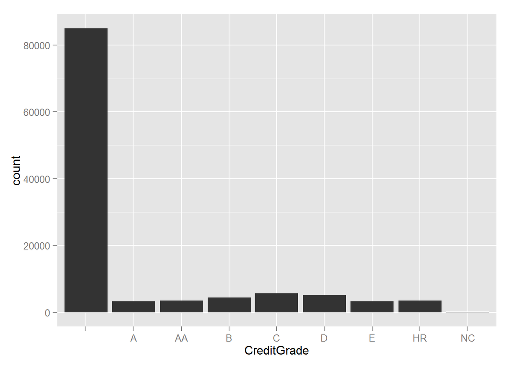

Urm.. Most of records without CreditGrade? It looks like it is due ‘Applicable for listings pre-2009 period and will only be populated for those listings.’ Try without NA data

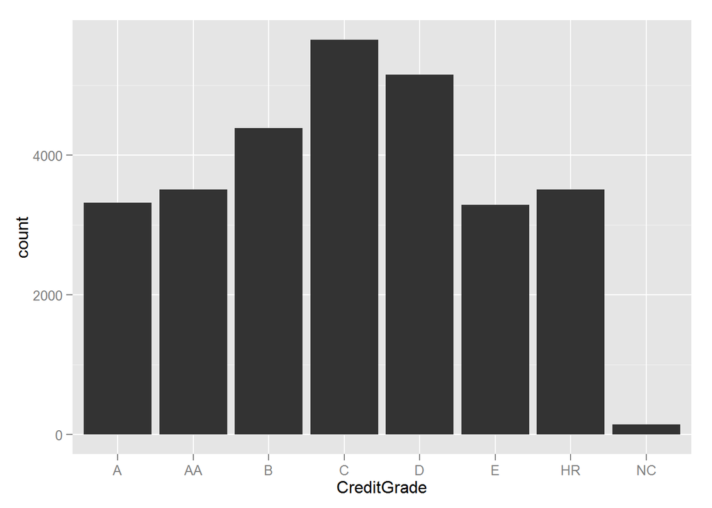

Ok. Further… Term in months

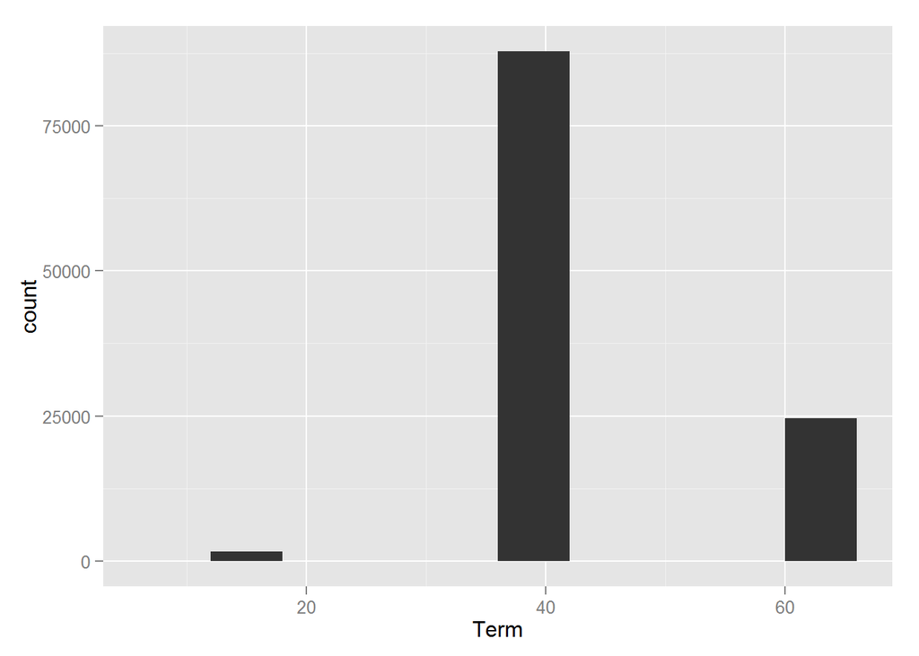

It looks like there are 3 standard terms. Check terms in years

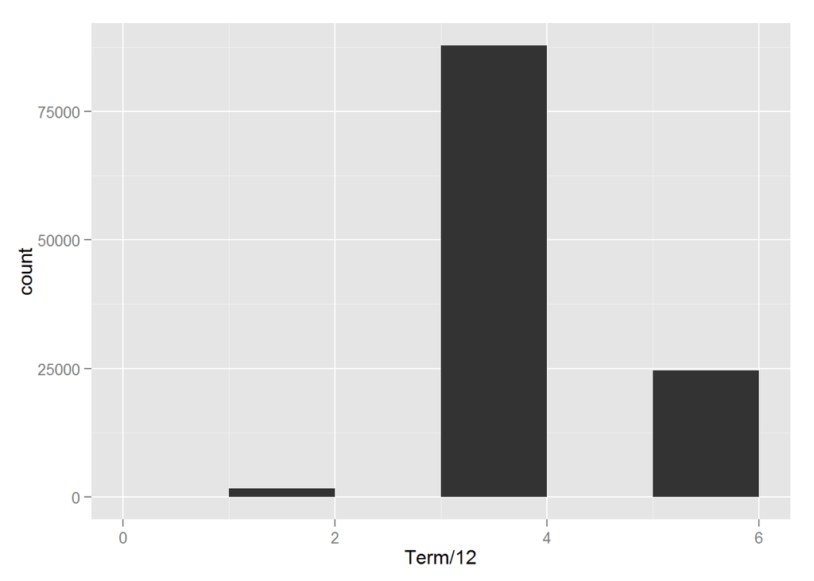

As it could be expected - 1, 3, and 5 years.

Categories of the listing: 0 - Not Available, 1 - Debt Consolidation, 2 - Home Improvement, 3 - Business, 4 - Personal Loan, 5 - Student Use, 6 - Auto, 7- Other, 8 - Baby&Adoption, 9 - Boat, 10 - Cosmetic Procedure, 11 - Engagement Ring, 12 - Green Loans, 13 - Household Expenses, 14 - Large Purchases, 15 - Medical/Dental, 16 - Motorcycle, 17 - RV, 18 - Taxes, 19 - Vacation, 20 - Wedding Loans

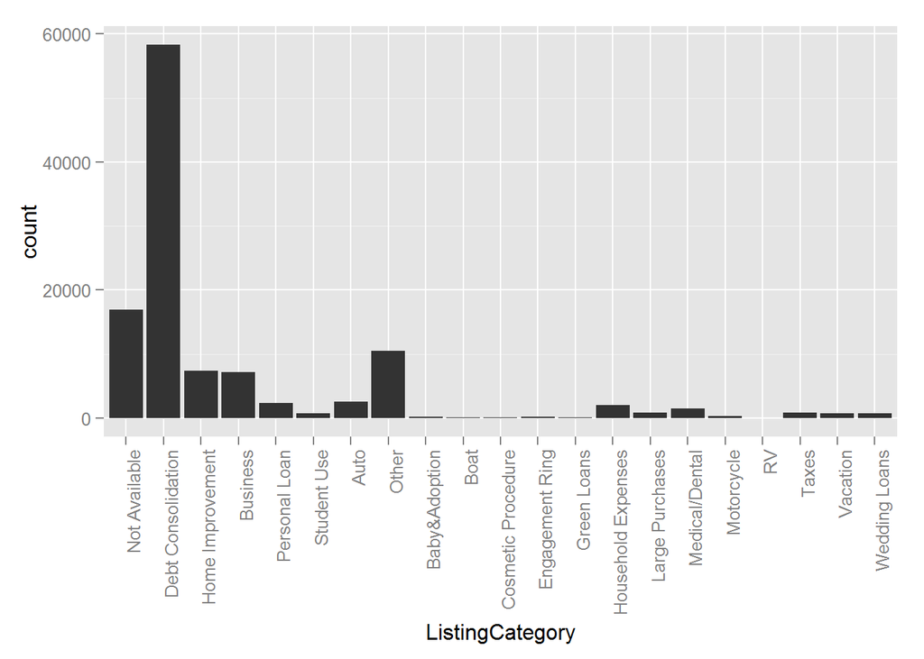

So top-3 reasons excluding N/A are following 1. Debt Consolidation 2. Other 3. Home Improvement

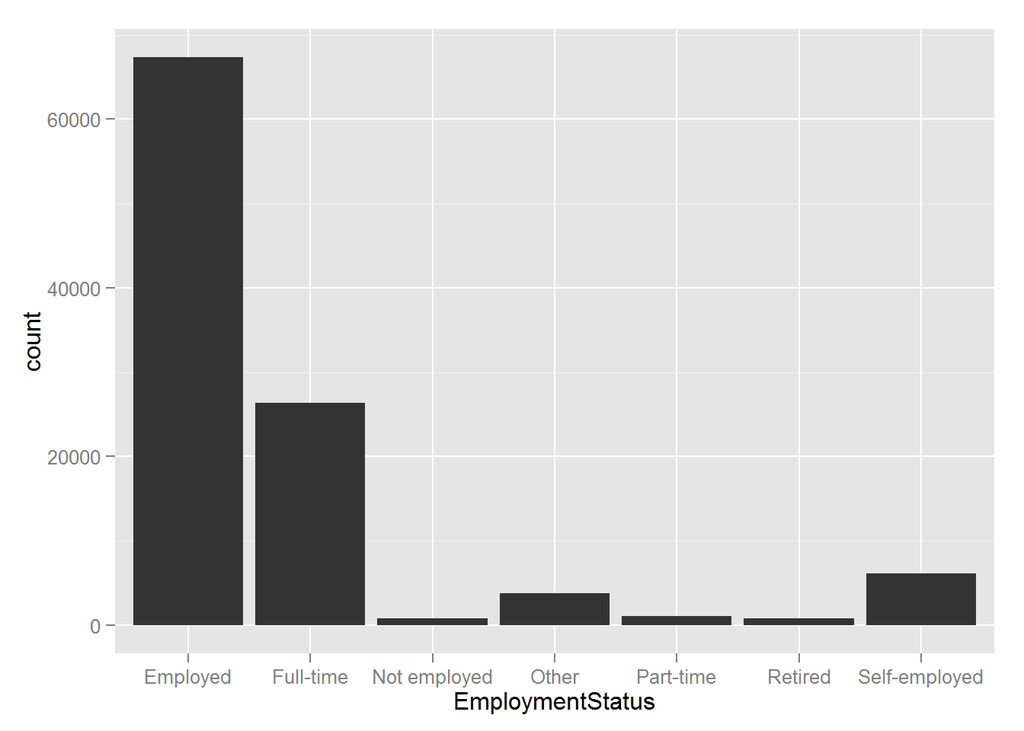

Not surprisingly that most of loans are for employed and full-time employed. Lender needs to be sure that loan will be payed. Most probability of returns for people who has costant income. Such people is employed.

```
## stat_bin: binwidth defaulted to range/30. Use 'binwidth = x' to adjust this.
```

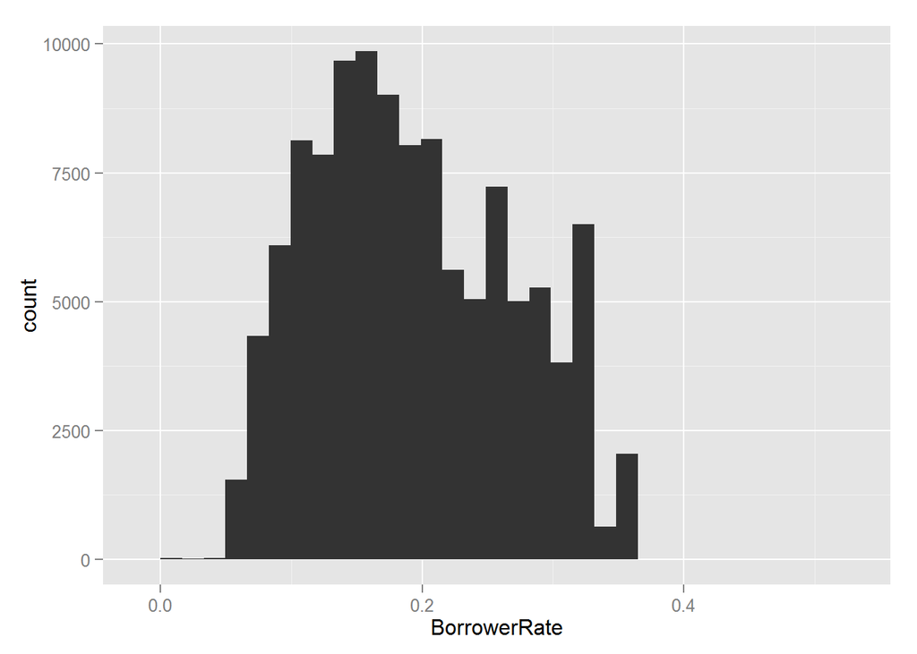

Explore it per possible groups. Starts with BorrowerRate per Term

```
## stat_bin: binwidth defaulted to range/30. Use 'binwidth = x' to adjust this.
## stat_bin: binwidth defaulted to range/30. Use 'binwidth = x' to adjust this.
## stat_bin: binwidth defaulted to range/30. Use 'binwidth = x' to adjust this.
```

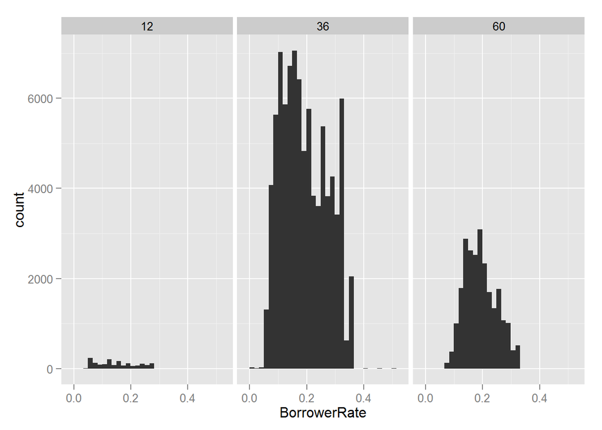

Continue with BorrowerRate per IncomeRange

[output not shown]

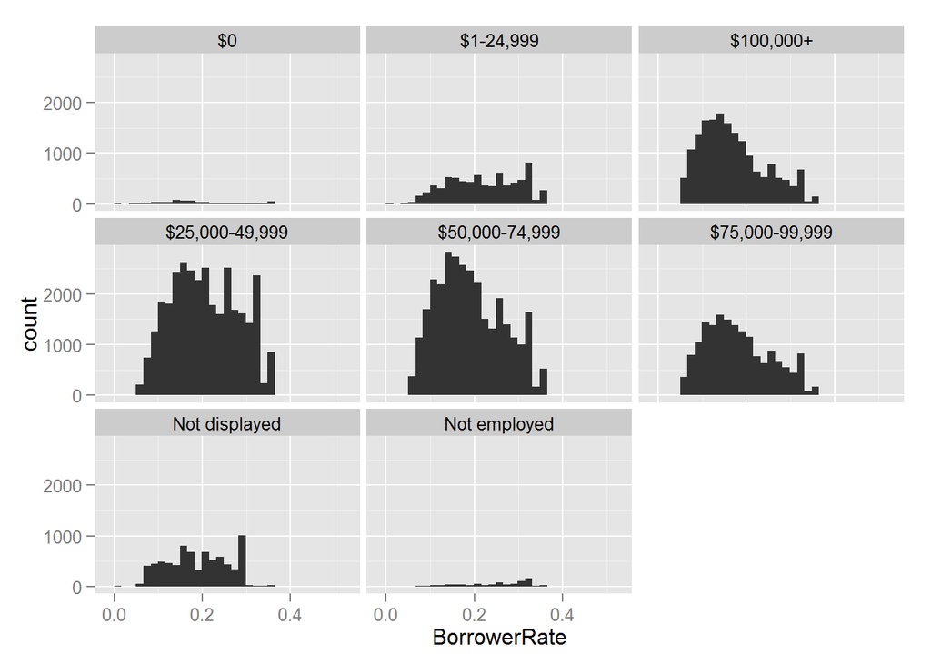

Check how DebtToIncomeRatio is distributed

```
## stat_bin: binwidth defaulted to range/30. Use 'binwidth = x' to adjust this.
```

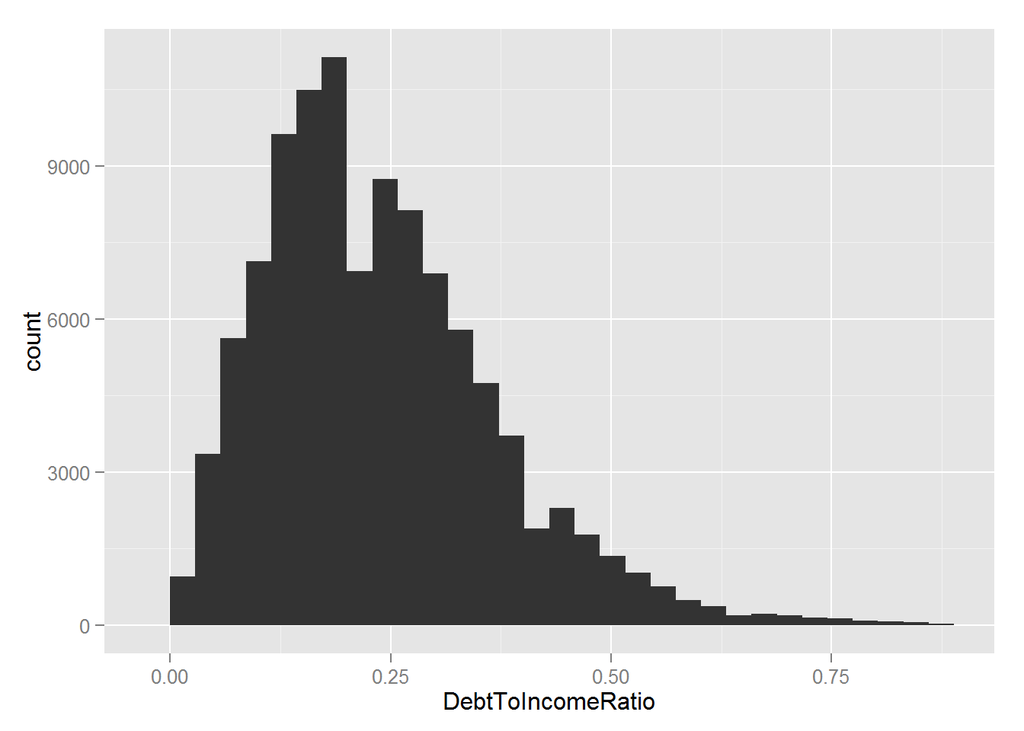

Looks like Poisson distribution. Check how LoanOriginalAmount is distributed

```
## stat_bin: binwidth defaulted to range/30. Use 'binwidth = x' to adjust this.
```

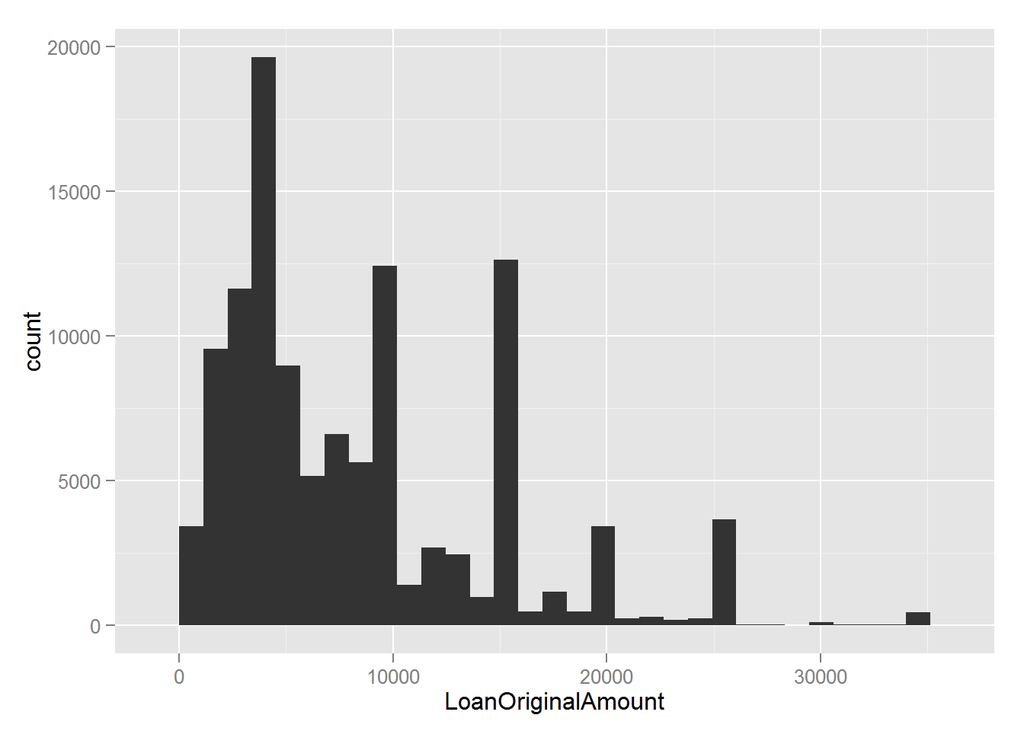

```
## stat_bin: binwidth defaulted to range/30. Use 'binwidth = x' to adjust this.
```

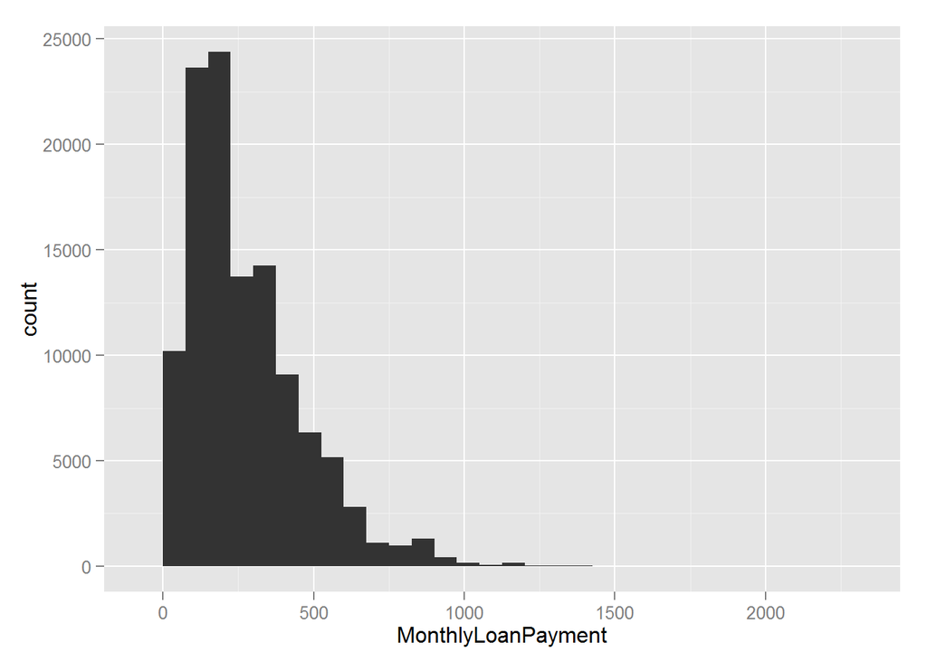

and IncomeRange

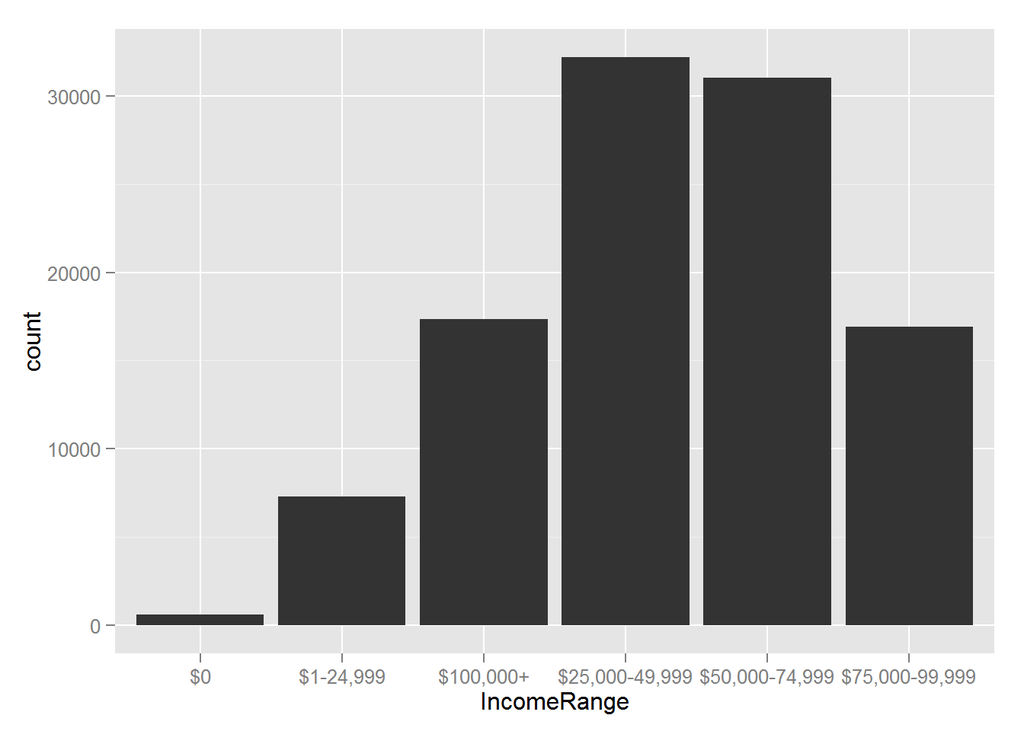

## Univariate Analysis

### What is the structure of your dataset?

There are more than 110 thousands observations with 81 variables.

### What is/are the main feature(s) of interest in your dataset?

Most interesting features I believe are BorrowerRate and LoanOriginalAmount. I am going to explore how other attributes affect them.

### What other features in the dataset do you think will help support your investigation into your feature(s) of interest?

For the first glance they are: - Term - ListingCategory - EmploymentStatus - DebtToIncomeRatio - IncomeRange

## Bivariate Plots Section

Start with checking BorrowerRate per ListingCategory

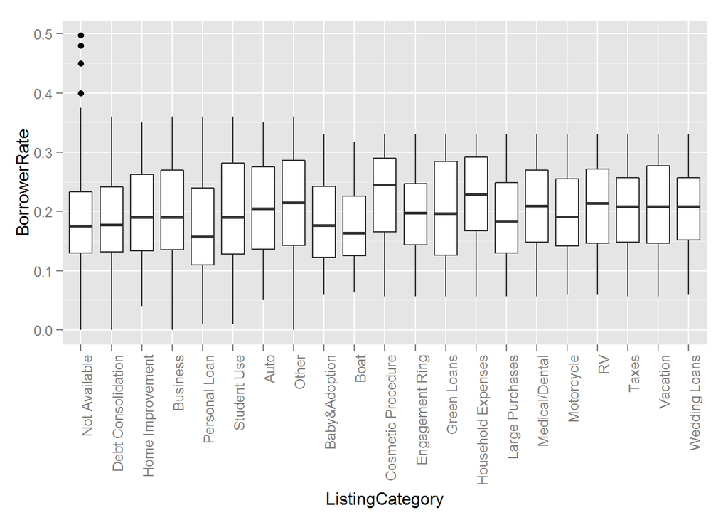

Rate differs slightly on purpose of loan. Most expensive rates for Cosmetic Procedures and Houshold Expenses. Those purposes are considere too risky and so rate is high. Cheapest loan is Personal Loan. I believe it is due lender and borrower know each other well enough to be sure in borrowers ability to return. Continue with LoanOriginalAmount per ListingCategory

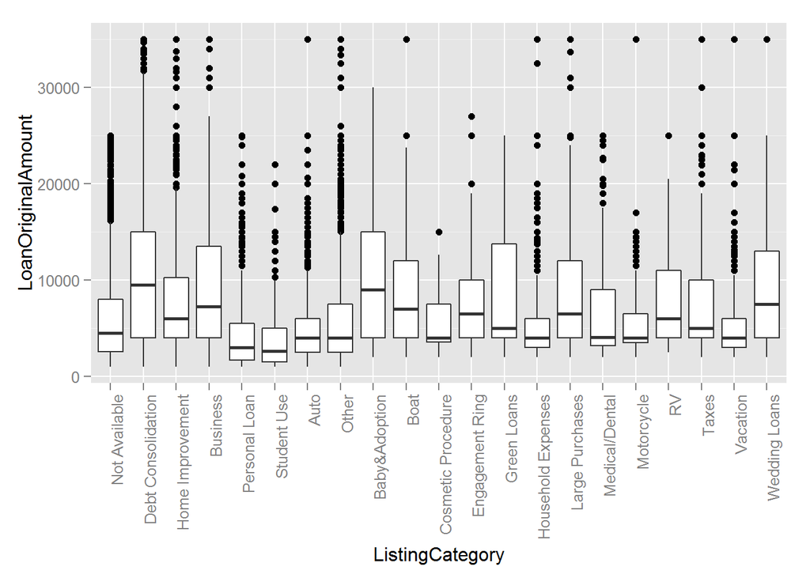

Check how BorrowerRate changes with LoanOriginalAmount

```
## geom_smooth: method="auto" and size of largest group is >=1000, so using gam with formula: y ~ s(x, bs = "cs"). Use 'method = x' to change the smoothing method.
```

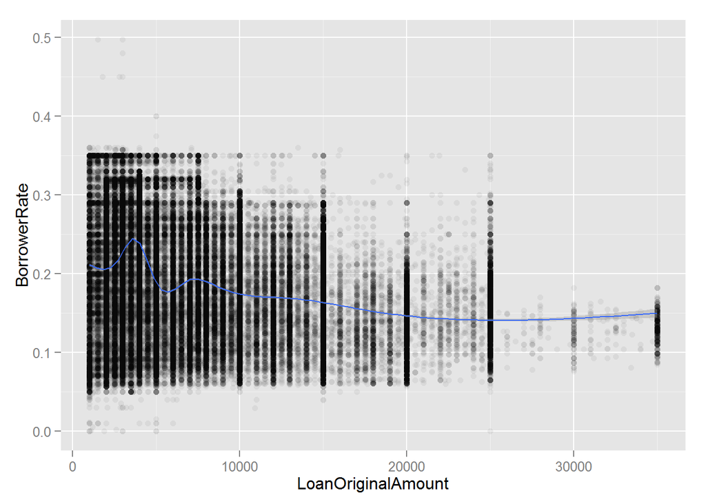

Consider dataset from another point. Per EmploymentStatus groups. Start with BorrowerRate

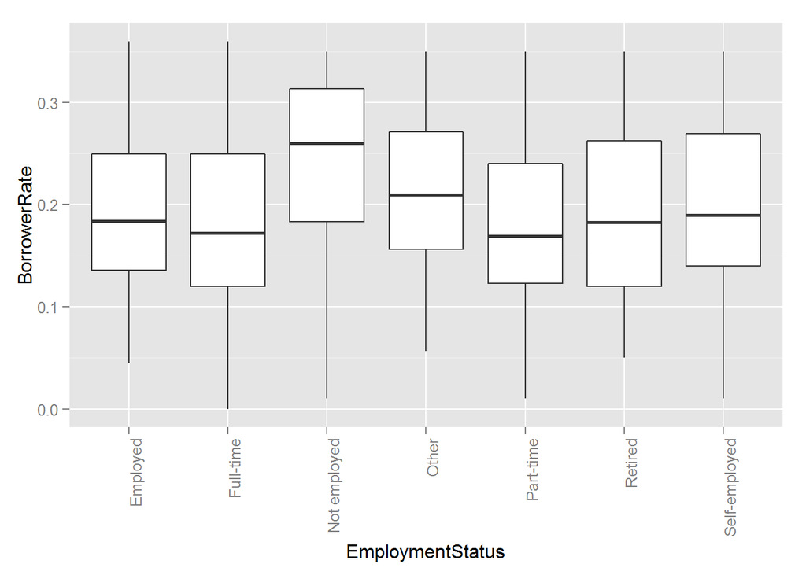

Continue with LoanOriginalAmount

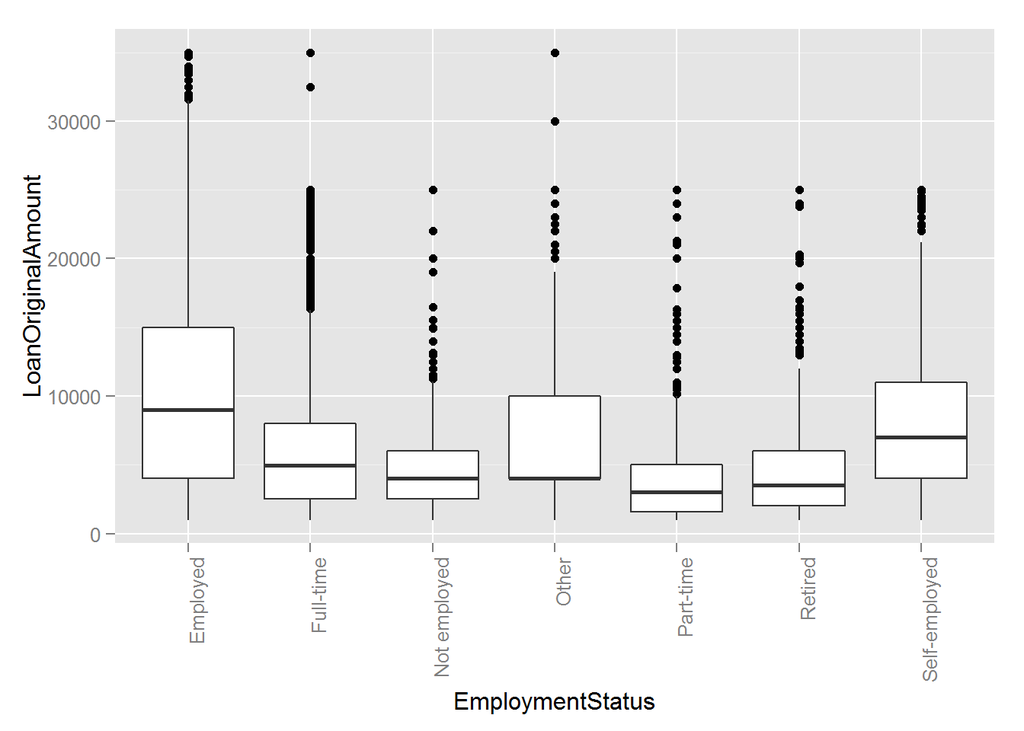

Now check BorrowerRate from DebtToIncomeRatio.

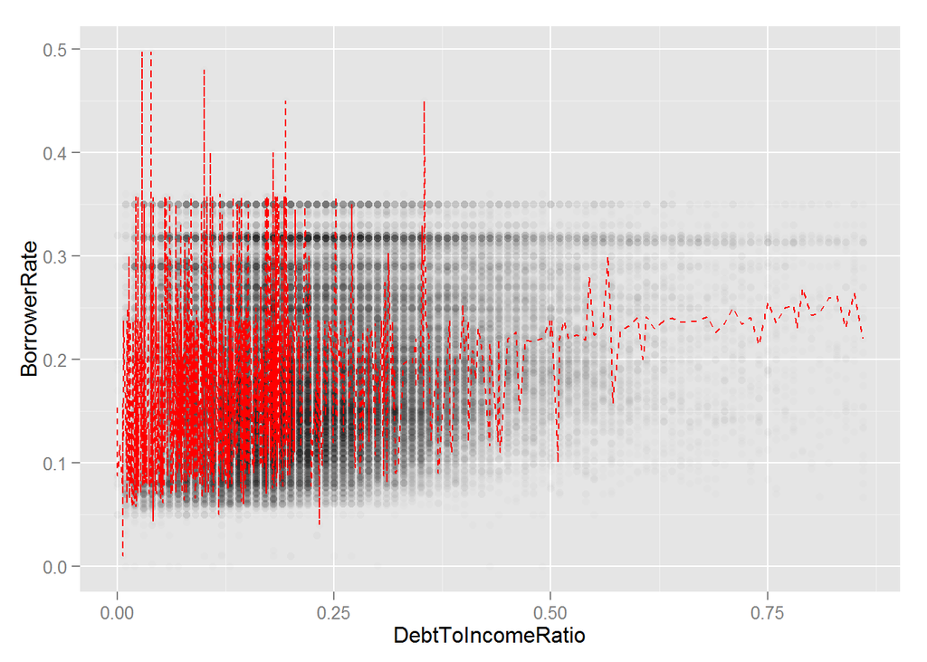

Urm… It looks like we need smoothing

```
## geom_smooth: method="auto" and size of largest group is >=1000, so using gam with formula: y ~ s(x, bs = "cs"). Use 'method = x' to change the smoothing method.
```

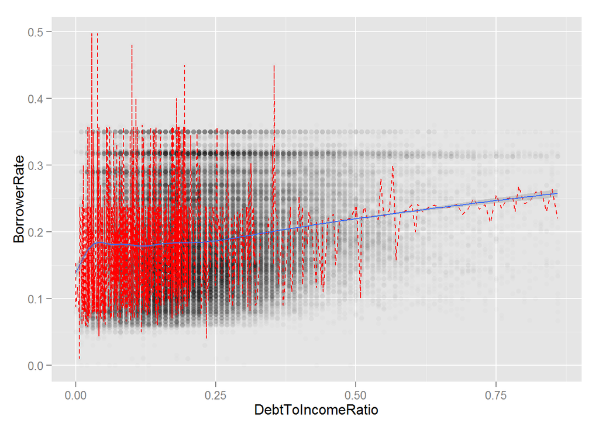

Remove original mean line smoothing

```
## geom_smooth: method="auto" and size of largest group is >=1000, so using gam with formula: y ~ s(x, bs = "cs"). Use 'method = x' to change the smoothing method.
```

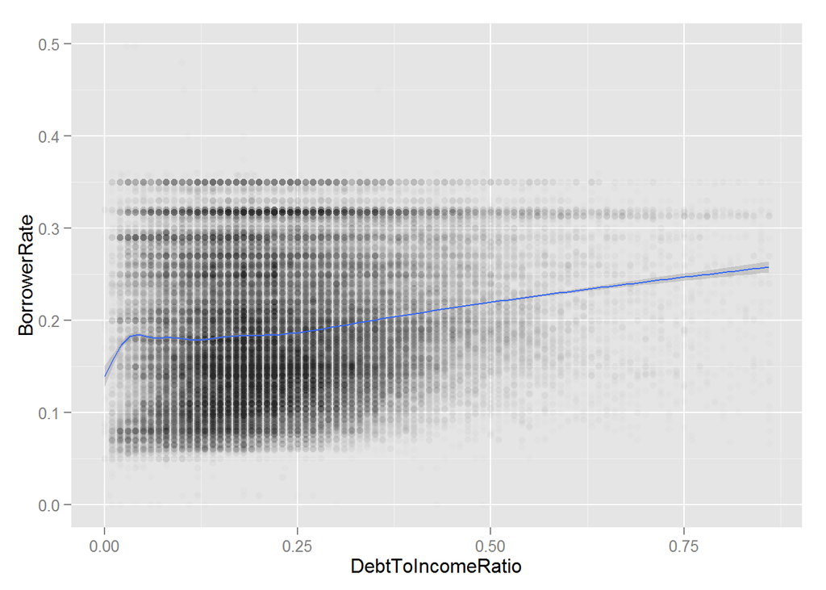

Now it is obvious that rate is growing with growth of DebtToIncomeRatio.

Now check a few more dependencies to see if we can find anything interesting.

LoanOriginalAmount ~ IncomeRange

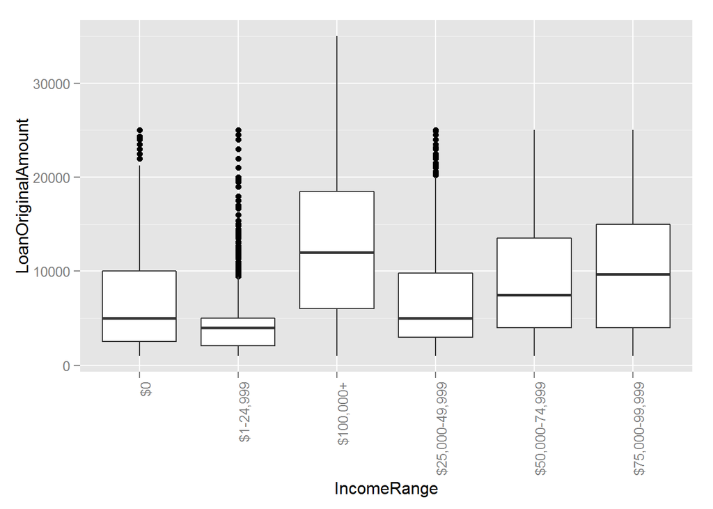

BorrowerRate ~ IncomeRange

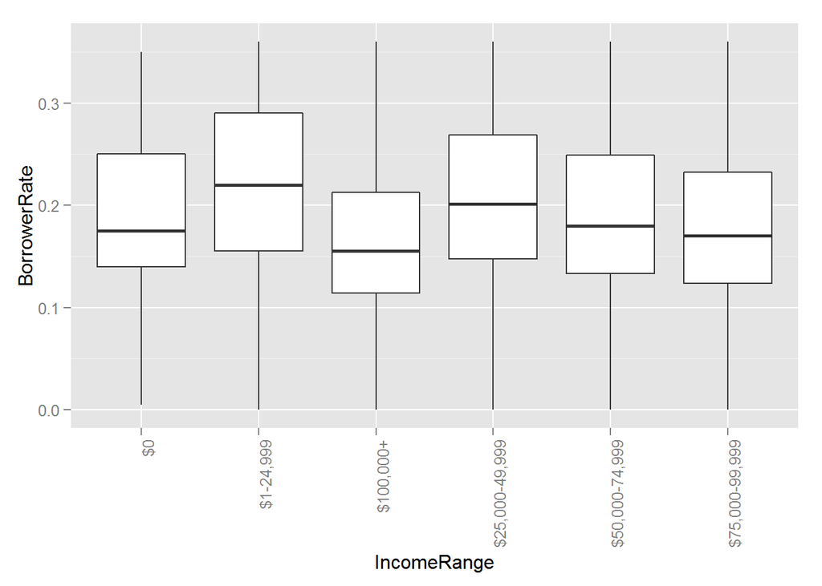

LoanOriginalAmount ~ Term

```
## geom_smooth: method="auto" and size of largest group is >=1000, so using gam with formula: y ~ s(x, bs = "cs"). Use 'method = x' to change the smoothing method.
```

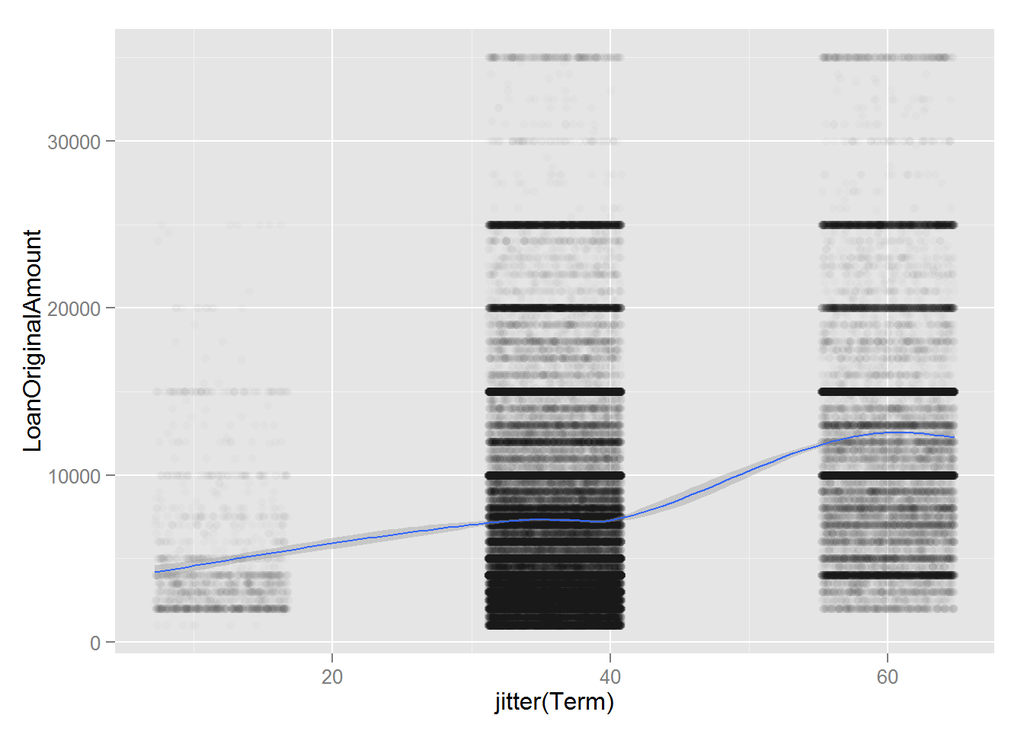

LoanOriginalAmount grows with Term

BorrowerRate ~ Term

```
## geom_smooth: method="auto" and size of largest group is >=1000, so using gam with formula: y ~ s(x, bs = "cs"). Use 'method = x' to change the smoothing method.
```

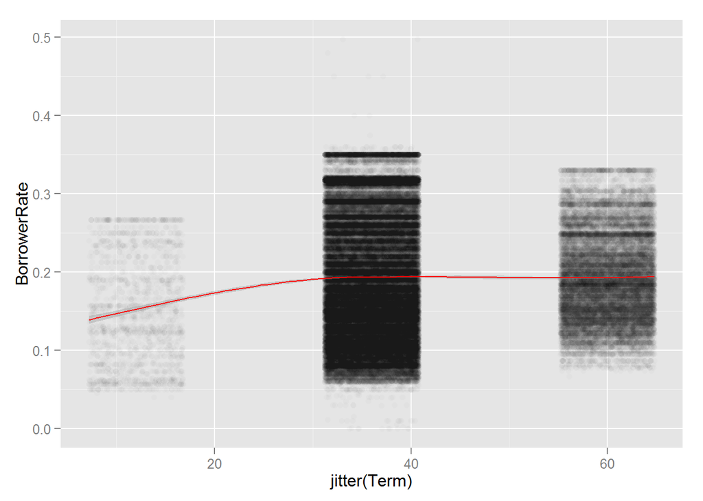

BorrowerRate gorws with Term from 1 till 3 years and further remains about constant

## Multivariate Plots Section

I’m providing graph advised by tutor.

```
## geom_smooth: method="auto" and size of largest group is >=1000, so using gam with formula: y ~ s(x, bs = "cs"). Use 'method = x' to change the smoothing method.
```

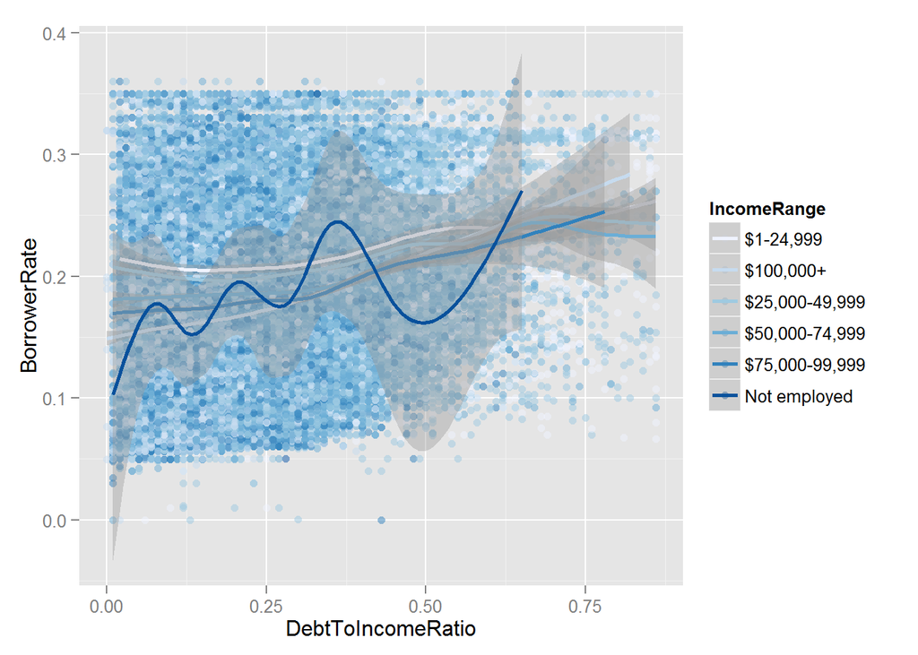

For most of groups BorrowRate grows with DebtToIncomeRatio. Point that meets 0 is higher with lower IncomeRange. It is interesting curve for Not employed group. It is not monotone. I think it is due other attributes affects much BorrowRate for this group.

# Final Plots and Summary

## Plot One

```
## stat_bin: binwidth defaulted to range/30. Use 'binwidth = x' to adjust this.
## stat_bin: binwidth defaulted to range/30. Use 'binwidth = x' to adjust this.
## stat_bin: binwidth defaulted to range/30. Use 'binwidth = x' to adjust this.
```

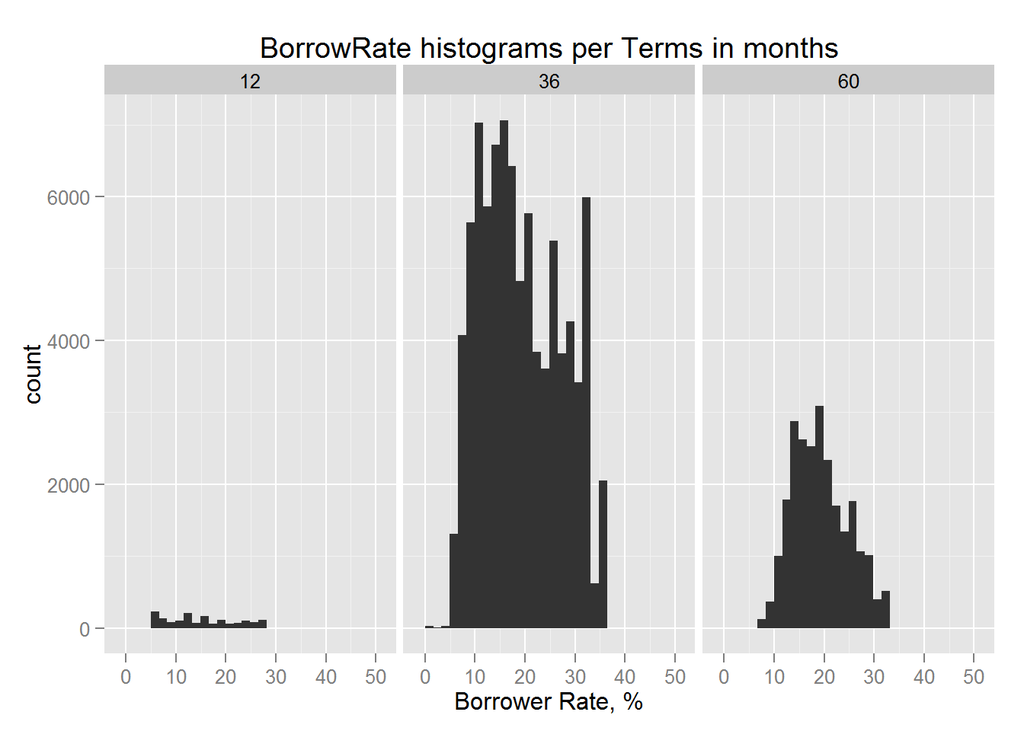

## Plot Two

```
## geom_smooth: method="auto" and size of largest group is >=1000, so using gam with formula: y ~ s(x, bs = "cs"). Use 'method = x' to change the smoothing method.
```

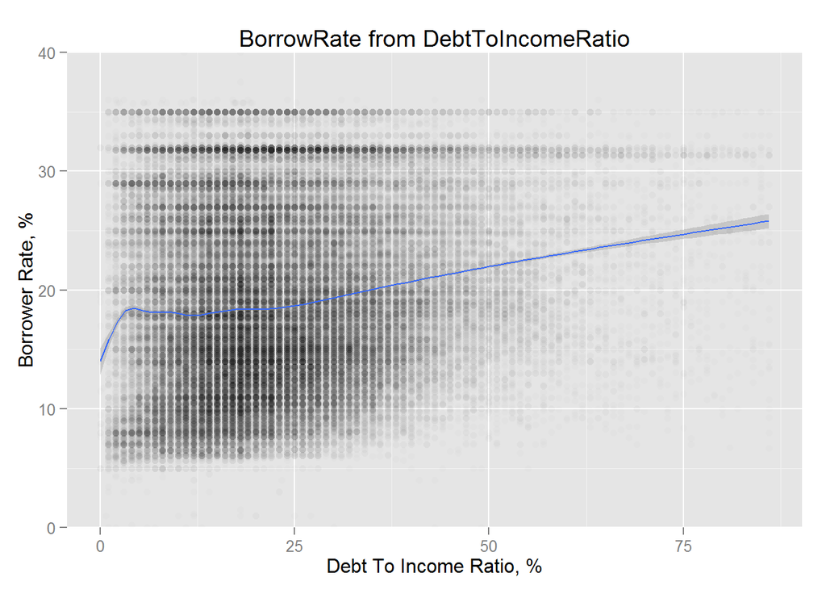

## Plot Three

```
## geom_smooth: method="auto" and size of largest group is >=1000, so using gam with formula: y ~ s(x, bs = "cs"). Use 'method = x' to change the smoothing method.
```

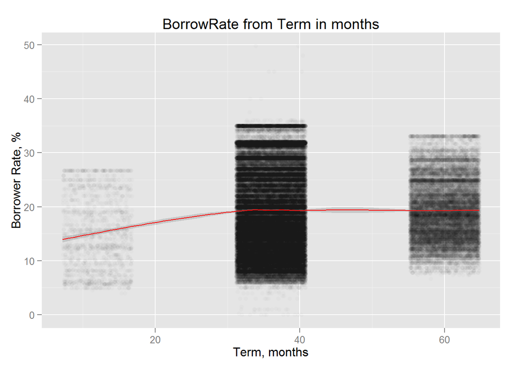

# Reflection